# ECOM30004/90004 Time Series Analysis and Forecasting Tutorial 1 Tutor: Pengyun (Kevin) Chen University of Melbourne Semester 2, 2026

## Notice

**Conditions of Use**

- This document is intended for personal use and is NOT meant to be shared on the internet (e.g. Studocu, ThinkSwap, StudentVIP, Coursehero, etc.)
- Do not share this document with anyone, even if they are enrolled in ECOM30004/90004.
- Official course materials, such as lecture slides, tutorial sheets and prescribed readings should always be your primary point of reference.

## A little about me…

- Pengyun (Kevin) Chen
- I am a third-year PhD student in Economics.
- My research interests are financial econometrics, empirical macro, and more recently, energy economics and sustainable finance.

**Help me help you**

Please let me know if:

- you have got questions to ask and/or I have made some mistakes
- you want me to repeat something
- you have general feedback/suggestions on improvements

I really value and appreciate that!

- Get in touch: `kevin.chen10@unimelb.edu.au`

## Tutorial Preparation and Expectations

- Tutorials start in Week 1. I take two tutorials each week:

  | Day/Time | Location | Tutorial Code |
  | --- | --- | --- |
  | Wednesday 1:00pm | The Spot-3014 | T01/06 |
  | Wednesday 2:00pm | The Spot-3014 | T01/05 |

- The software used for ECOM30004/90004 are **R and RStudio**, so these should be installed onto your computer as you will need them for completing tutorial tasks and assignments.
- From Week 2 the tutorial will build on the lecture and self-directed activities from the previous week. You are expected to have attended or viewed the lecture and carried out the self-directed activities.
- There will be a weekly homework submission following each tutorial, starting from Week 2. (more on next slide)

## Tutorial Attendance and Homework (10% Assessment)

- You should attend the tutorial you are officially enrolled in.
  - You must contact me in advance (e.g. by email) if you need to attend one of my other tutorial sessions.
  - Approval is subject to available capacity and obtained on a weekly basis.
- **Starting from Week 3**, each week there will be 1 mark allocated if you *both*
  - attend the tutorial, *and*
  - by 11am Monday submit solutions to the previous week’s self-directed activities on the LMS.
  - **Example:** the second self-directed activities will be first to be submitted, by Monday 11am of Week 3.

## This tutorial

- This tutorial will revise/introduce some relevant R commands for this subject.
- Introduce data on Retail sales for Australia that will be used for the first forecasting application in this subject.
  - Retail sales are considered a key indicator of the health of an economy, and are commonly a target of interest for commercial forecasters.

Before starting with the questions, let’s warm up by setting up our workspace in RStudio. Usually the first step is to set up the **working directory**.

### Warming Up: Setting Up Working Directory in R

Setting up the working directory ensures that R can accurately locate where your data files are stored. It defines where R looks for files and where it saves outputs.

To set up your working directory, enter command:

```r
setwd("Your location goes here")
```

Alternatively, you can click on:
$$\boxed{\;\textsf{Session}\;}\;\;\to\;\;\boxed{\;\textsf{Set Working Directory}\;}\;\;\to\;\;\boxed{\;\textsf{Choose Directory}\;}$$

### Warming Up: Checking Working Directory in R

To check your working directory, enter `getwd()` into your Console tab:

```r
getwd()
```

```
[1] "/Users/chenpengyun/Desktop/ECOM30004_Tutoring_2026/TSAF_Week1"
```

If the folder looks correct, you can proceed to loading the datasets and files.

## Warming Up: Some Useful Functions

```r
help(aggregate)
?aggregate           # Same as help() function
??aggregate          # If you want to know which package it is from
```

## Question 1

Obtain the data file `RetailSales.csv`, and save it into an appropriate working directory. Read the data into an R dataframe. To get a sense of the variables in the dataframe, use the `head()` command to print out the first six rows of the dataframe.

```r
# Read data file and create monthly ts object
dt <- read.csv("RetailSales.csv")
print(head(dt))
```

```
    Date   Food Hhold Clothing DeptStores Other Restaurants  Total
1 Apr-82 1162.6 592.3    359.9      460.1 479.1       342.4 3396.4
2 May-82 1150.9 629.6    386.6      502.6 486.1       342.1 3497.9
3 Jun-82 1160.0 607.4    350.5      443.8 467.5       328.7 3357.8
4 Jul-82 1206.4 632.4    359.3      459.1 491.1       338.5 3486.8
5 Aug-82 1152.5 622.6    325.2      438.4 485.7       331.5 3355.9
6 Sep-82 1189.1 622.0    346.3      465.1 489.9       341.9 3454.3
```

## Question 2

We will focus on the time series of Total retail sales. Create a time series object for monthly total retail sales. Plot this time series.

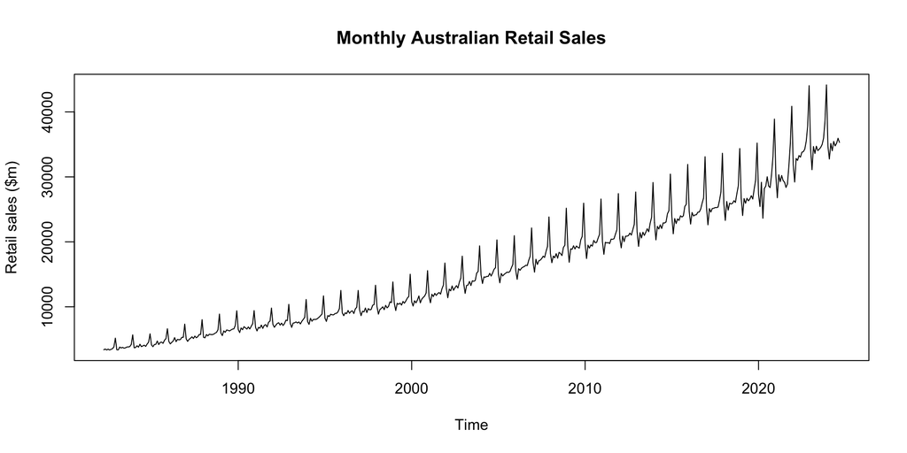

```r
Retail_m <- ts(dt$Total, frequency=12, start=c(1982,4), end=c(2024,9))
plot(Retail_m, main="Monthly Australian Retail Sales",
  ylab="Retail sales ($m)")
```

## Question 3(a)

Use `aggregate` to transform the monthly time series to quarterly frequency.

```r
Retail_q <- aggregate(Retail_m, nfrequency=4)
```

❓ What’s going on?

```r
print(Retail_m)
```

```
         Jan     Feb     Mar     Apr     May     Jun     Jul     Aug     Sep
1982                          3396.4  3497.9  3357.8  3486.8  3355.9  3454.3
1983  3384.5  3369.8  3805.3  3665.1  3760.0  3630.8  3686.5  3816.3  3823.4
1984  3698.5  3733.2  4010.9  3788.4  4242.3  3872.1  3978.0  4096.1  3901.4
1985  4130.0  3856.8  4196.9  4228.9  4739.1  4190.3  4514.6  4566.3  4380.3
1986  4674.9  4294.1  4528.0  4729.0  5261.9  4637.8  4989.5  4923.8  4962.2
1987  5065.3  4679.8  4993.0  5166.0  5386.3  5118.9  5494.6  5236.7  5395.1
1988  5304.4  5226.8  5729.7  5527.3  5787.8  5739.2  5722.7  5787.3  5946.3
1989  5980.3  5574.1  6299.0  6075.7  6437.8  6377.4  6287.5  6436.4  6565.5
1990  6511.6  6031.0  6749.3  6476.1  6947.9  6758.9  6573.5  6911.2  6589.3
1991  6837.2  6284.6  6837.9  6709.5  7191.7  6674.9  7147.0  7262.7  6898.1
1992  7305.3  6848.2  7164.6  7435.5  7551.4  7180.7  7487.0  7119.3  7406.0
1993  7455.9  6833.0  7497.4  7539.8  7675.2  7507.9  7674.2  7361.4  7765.5
1994  7730.6  7295.2  8240.1  7775.5  8061.2  8057.1  8076.6  8222.7  8410.6
1995  8268.3  7750.3  8656.9  8514.5  8860.4  8767.9  8762.1  8964.4  8996.2
```

[output cut: 73 more lines]

```r
print(Retail_q)
```

```
         Qtr1     Qtr2     Qtr3     Qtr4
1982           10252.1  10297.0  12561.7
1983  10559.6  11055.9  11326.2  13774.5
1984  11442.6  11902.8  11975.5  14678.6
1985  12183.7  13158.3  13461.2  16590.9
1986  13497.0  14628.7  14875.5  17948.6
1987  14738.1  15671.2  16126.4  19511.8
1988  16260.9  17054.3  17456.3  21422.5
1989  17853.4  18890.9  19289.4  23154.1
1990  19291.9  20182.9  20074.0  23819.6
1991  19959.7  20576.1  21307.8  25242.5
1992  21318.1  22167.6  22012.3  26212.7
1993  21786.3  22722.9  22801.1  27563.4
1994  23265.9  23893.8  24709.9  29229.2
1995  24675.5  26142.8  26722.7  31467.4
```

[output cut: 29 more lines]

`aggregate` generates a new series, `Retail_q`, by summing up the monthly observations of each quarter.

## Question 3(b)

Create a window of this quarterly time series from 2000q1 to 2018q4, and produce a time series plot.

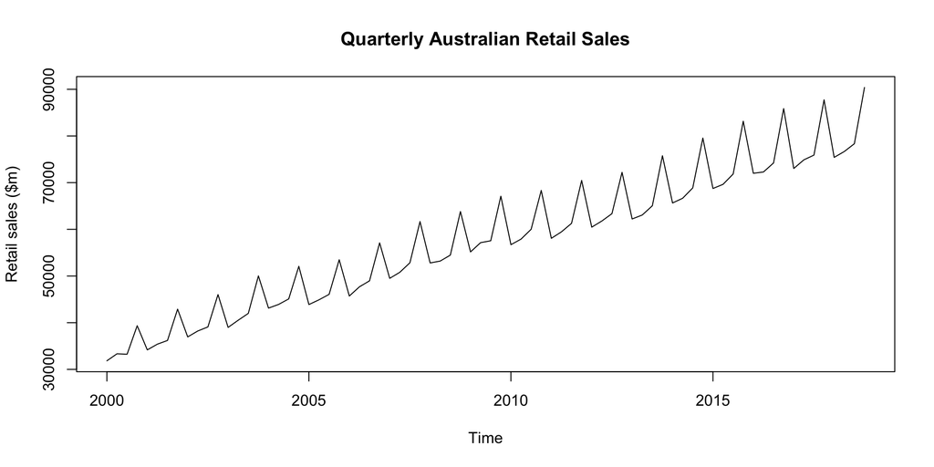

```r
S_t <- window(Retail_q, start=c(2000,1), end=c(2018,4))
plot(S_t, main="Quarterly Australian Retail Sales",
  ylab="Retail sales ($m)")
```

## Question 4

Take the log of the quarterly time series and produce a plot.

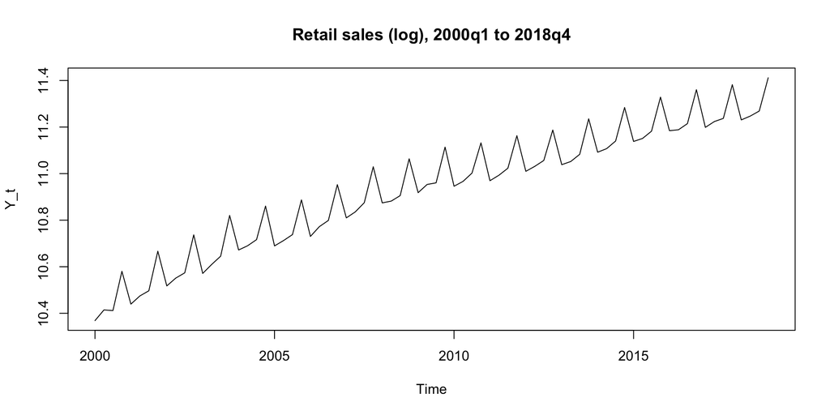

```r
Y_t <- log(S_t)
plot(Y_t, main="Retail sales (log), 2000q1 to 2018q4")
```

## Questions 5 and 6

Denote the log retail sales time series as $Y_{t}$. Create the *first difference* time series
$$\Delta Y_{t}=Y_{t}-Y_{t-1}$$
Print out the first six values of $Y_{t}$ and $\Delta Y_{t}$. What’s going on with the value of $\Delta Y_{t}$ for 2000q1?

```r
# First difference of quarterly log retail sales Y_t, convert to pct
D_Y_t <- diff(Y_t)*100
print(round(head(cbind(Y_t,D_Y_t)),4))
```

```
            Y_t    D_Y_t
2000 Q1 10.3685       NA
2000 Q2 10.4144   4.5997
2000 Q3 10.4116  -0.2842
2000 Q4 10.5805  16.8887
2001 Q1 10.4393 -14.1158
2001 Q2 10.4745   3.5186
```

The first value in `D_Y_t` is missing (`NA`) because there is no value of `Y_t` available before 10.3685 to compute the difference. Taking a difference of a time series will necessarily result in a shorter time series because of this.

## Question 7

Denote the quarterly retail sales time series by $S_{t}$. Create a time series of the quarterly percentage change (growth rate) of this time series, that is
$$R_{t}=\frac{S_{t}-S_{t-1}}{S_{t-1}}\times 100\%.$$
Compare the values of $\Delta Y_{t}$ and $R_{t}$.

```r
# Percentage change of retail sales
R_t <- diff(S_t)/lag(S_t,-1)*100
# Compare
print(round(head(cbind(D_Y_t, R_t)),4))
```

```
           D_Y_t      R_t
2000 Q2   4.5997   4.7071
2000 Q3  -0.2842  -0.2838
2000 Q4  16.8887  18.3986
2001 Q1 -14.1158 -13.1648
2001 Q2   3.5186   3.5813
2001 Q3   2.2103   2.2349
```

## Question 7

Denote the quarterly retail sales time series by $S_{t}$. Create a time series of the quarterly percentage change (growth rate) of this time series, that is
$$R_{t}=\frac{S_{t}-S_{t-1}}{S_{t-1}}\times 100\%.$$
Compare the values of $\Delta Y_{t}$ and $R_{t}$.

What does `lag(S_t, -1)` function do?

```r
print(head(cbind(lag(S_t,-1),S_t)))
```

```
        lag(S_t, -1)     S_t
2000 Q1           NA 31839.1
2000 Q2      31839.1 33337.8
2000 Q3      33337.8 33243.2
2000 Q4      33243.2 39359.5
2001 Q1      39359.5 34177.9
2001 Q2      34177.9 35401.9
```

## Question 7 ctd: Why the comparison?

- Adding 1 on both sides and take logs:
  $$\begin{align}
  R_{t}&=\frac{S_{t}-S_{t-1}}{S_{t-1}}\\
  1+R_{t}&=\frac{S_{t}}{S_{t-1}}\\
  \log(1+R_{t})&=\log(S_{t})-\log(S_{t-1})\\
  \log(1+R_{t})&=Y_{t}-Y_{t-1}\equiv\Delta Y_{t}
  \end{align}$$
- Then with the approximation $\log(1+R_{t})\approx R_{t}$ for small values of $R_{t}$, we have $R_{t}\approx \Delta Y_{t}$:
  $$\text{$R_{t}\approx\log(1+R_{t})$}= \Delta Y_{t}$$

## Question 7 continued

Why is $\ln(1+x)\approx x$ for small values of $x$?

[interactive chart not shown]

## Question 7 ctd: Some further observations (1/2)

Denote the quarterly retail sales time series by $S_{t}$. Create a time series of the quarterly percentage change (growth rate) of this time series, $R_{t}=\frac{S_{t}-S_{t-1}}{S_{t-1}}\times 100\%$.

Compare the values of $\Delta Y_{t}$ and $R_{t}$.

The values of $\log S_{t}-\log S_{t-1}$ and $R_{t}=(S_{t}-S_{t-1})/S_{t-1}$ are quite similar especially for the smaller changes.

For the entire time series the two variables are very highly correlated:

```r
print(cor(R_t, D_Y_t))
```

```
[1] 0.9985674
```

```r
print(round(cor(R_t, D_Y_t), 3))
```

```
[1] 0.999
```

## Question 7 ctd: Some further observations (2/2)

The values of $\log S_{t}-\log S_{t-1}$ and $R_{t}=(S_{t}-S_{t-1})/S_{t-1}$ are quite similar especially for the smaller changes.

This is also evident in the plot shown below:

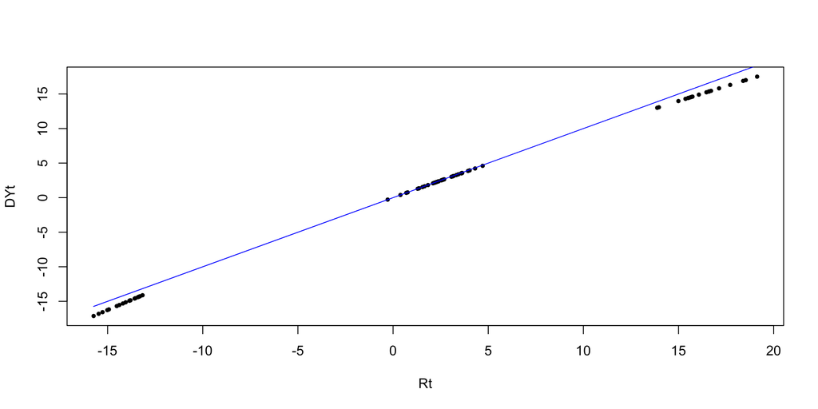

```r
plot(as.numeric(R_t), as.numeric(D_Y_t), pch=16, cex=0.7,
     xlab="Rt", ylab="DYt")
lines(as.numeric(R_t), as.numeric(R_t), col="blue")
```

## Question 7 ctd: Why taking logs differences?

- Taking log differences or simple returns is a common type of “filtering” in time series analysis.
- Filtering tends to stablise/linearise features such as trend and seasonality.
- Changes in a logged time series can be interpreted as approximately percentage changes, which is often convenient.
- Also, time series models, such as AR models and VAR models, requires data to be *stationary* $\to$ filtering/transformation ensures this requirement is met.

Thank you for coming!